# Presentación

Módulo práctico de ITA  
(Grupo M)

# Bienvenidos !! 🖖🌹

… y prácticamente a la **Universitat de València**

## Un poco de información sobre mi

- Pedro J. Pérez (pedro.j.perez@uv.es)
- Habitualmente doy la asignatura de **Econometría**, pero …
- … este curso doy otras 2 asignaturas:
  - **Programación y manejo de datos** (optativa de 4º. GECO)
  - **TIC’s** (troncal de 2º curso. GTUR)
- Entusiasta de R

### Mis objetivos/esperanzas con el curso

- Que **aprendáis a manejar datos con R**
- Espero que os **sea útil en el futuro**
- Que os guste R
- Que os divirtáis con R

## ¿Qué vamos a hacer en el modulo práctico de ITA?

- Aprender a **programar en R** para analizar y manejar datos

> Recomendaciones de la CAT:
1. Enseñanza de la economía motivada por **problemas y datos del mundo real**.
2. Potenciar el **análisis y gestión de datos con R**

### Para analizar datos, ¿realmente necesito aprender R?

**SÍ**

### ¿Por qué necesito aprender R?

- Estamos inmersos en una época de cambio tecnológico acelerado, conocida como la **era del Big Data**.
- Una parte importante de esos avances están relacionados con la **abundancia de datos**.

> “The world’s **most valuable resource** is no longer oil, but **data**” (The Economist, 2017).
- Necesidad de **convertir datos en información** que aporte valor a las corporaciones.
- Aparición de un nuevo campo de conocimiento que está irrumpiendo con fuerza en muchos planes de estudio: la **Ciencia de Datos**
- Para hacer “Ciencia de Datos” **es necesario programar**. Y R es uno de los lenguajes más utilizados en este campo.

### Ser “cientifico de datos” ¿es un buen trabajo?

- “The **data scientist** is the **sexiest job** of the century” : [Harvard Business Review (2012)](https://hbr.org/2012/10/data-scientist-the-sexiest-job-of-the-21st-century).
- Según [este artículo de HBR](https://hbr.org/2022/07/is-data-scientist-still-the-sexiest-job-of-the-21st-century), parece que **en 2022** todavía sigue siendo un empleo muy demandado.

#### Para trabajar en DS, ¿qué necesito saber?

- Para un data scientist son muy importantes las hackings skills (programación)

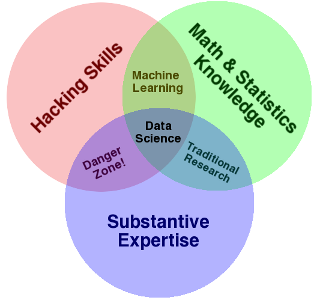

### Forma de trabajar con el “entorno R”

- **R es un entorno** (y un lenguaje de programación) **para hacer estadística**
- Podemos pensar que un **análisis con datos** tiene varias etapas.

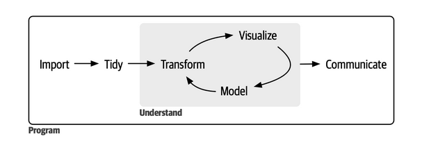

### En resumen: el modulo práctico de ITA es . . .

- Una introducción a la Ciencia de Datos
- Para ello hace falta “programar”. Utilizaremos R.
- El énfasis se pondrá, en desarrollar competencias/conocimientos prácticos para “manejar” datos.
- Para “aprender” estas habilidades se han de practicar.
- **El trabajo en clase y fuera de clase es muy importante!!**
- Espero que aprendáis y que os guste … en realidad, espero que NOS divirtamos!!

# Datos prácticos

### Detalles del curso

- ITA: modulo teórico y **modulo práctico**
- Clases: lunes por la tarde (3 subgrupos)
- **Calendario**: 13 semanas (+1, el 22 de Diciembre)
- **Importancia del trabajo con ordenador**. Es necesario tener un ordenador con R y RStudio instalados, tanto en casa con en el aula.
- Mandaré tareas para la semana siguiente!!
- **Tutorías**: Martes de 17:30 a 18:30 y Miércoles de 10:30 a 12:30 despacho 3P13B
- **Bibliografía**: [R for Data Science](https://r4ds.hadley.nz/) de Hadley Wickham y Garrett Grolemund. [Aquí](https://es.r4ds.hadley.nz/) la primera edición en castellano

### Evaluación de ITA

- 30% examen final + **70% evaluación continua**

(Hace falta aprobar el examen final para superar la asignatura)

- **Evaluación continua** (70%):
  - 20% modulo teórico
  - **50% modulo práctico**

### Evaluación del **modulo práctico de ITA**

- Aporta un 50% de la nota de ITA

Ese 50% se compondrá de:

- Asistencia (1,5 puntos)
- Tareas a resolver en el aula (1 punto)
- Tareas para casa (1 punto)
- [Proyecto](https://perezp44.github.io/intro-ds-23-24-web/05-trabajos-estudiantes.html) en grupo (3 personas) (1,5 puntos)

Si no se pudiesen hacer los trabajos, entonces:

- Asistencia (2 puntos)
- Tareas a resolver en el aula (1,5 puntos)
- Tareas para casa (1,5 puntos)

# Comenzamos el curso !!!! 💻🤞 💪🏼 💪🏼